# Apply Function

There are lot of uses of apply familiy in R . The functions in apply family are very good alternative to for loop. Here I am going to talk about apply function. Apply function is useful when we need to peform somthing each each column in a 2 dimensional matrix , 3 dimensional matrix or a 3 dimensional list.

Lets generate this random data first.

```r
x1=rnorm(30,0,1)
x2=rt(30,2)

x3=data.frame(x1,x2)
```

So in this new data frame , there are 2 columns. Lets say that you need to perform some operation for each column in the data frame.

As an example let calculate the mean and variance of each column. We can do this using apply function as follows.

```r
apply(x3,2,mean)
```

```
##         x1         x2
## 0.05978643 0.37496182
```

```r
apply(x3,2,var)
```

```
##       x1       x2
## 1.123812 3.901557
```

```r
apply(x3,1,mean)
```

```
##  [1] -0.43717702 -0.91519762  0.65814170  1.36652625 -0.50265349
##  [6] -0.47479461  0.23593273  2.23978754  1.37522768  0.19845028
## [11] -0.52855423 -0.18706804 -0.08835547  4.18802350 -0.85807823
## [16] -1.08896538 -0.39508928  1.12140640  0.73457026 -1.01169405
## [21] -0.83797128 -0.83458798 -0.14454550  0.37133726 -0.18941656
## [26]  1.67442352  0.40723431  0.63487842  0.20150767 -0.39207510
```

Similar to this , we can perform any user defined function. For example here we have plotted each column as follows,

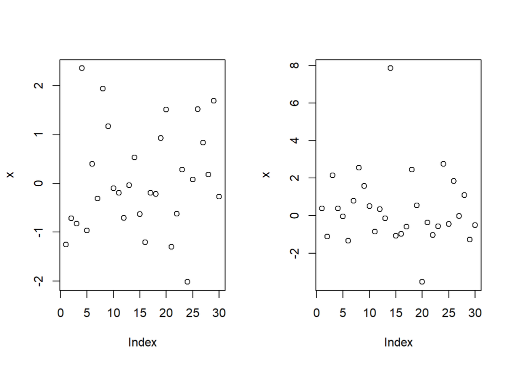

```r
par(mfrow = c(1,2) )
apply(x3,2, function(x)
plot(x))
```

Apply function is very useful when we have a 3 dimensional martix or a list. Cosnider the following example. For this you should first install mvtnorm package to R.

```r
library("mvtnorm", lib.loc="~/R/R-3.5.1/library") #first install mvtnorm package
mu=c(0,1) #mean vector
sig=matrix(c(1,0.8,0.8,1),nrow = 2,byrow = T) #covariance matrix
data1=rmvnorm(30,mu, sig)
data2=rmvt(30, sig,df=2)
data=list(data1,data2 )
```

In this example we have generated a 3 dimensional matrix with bivariate normal and bivariate t data corresponding to a mean vector and a covariance matrix. If we need to perform the shapiro wilk normality test for each dimension, it can be done as follows,

```r
lapply(data, function(x)
                apply(x,2,function(y)
                          shapiro.test(y)$p.value))
```

```
## [[1]]
## [1] 0.03075425 0.79673428
##
## [[2]]
## [1] 0.008920397 0.887175667
```

Here we have used the lapply function because the data is in a form of a list.